# era

Andrew Martin

May 6, 2015

first, read in the data prep in the other .Rmd:

```r
knitr::knit('stat_avg.Rmd', tangle=TRUE)
```

[output not shown]

```
## [1] "stat_avg.R"
```

```r
source('stat_avg.R')
```

```
## [1] "AVG"
## [1] "R"
## [1] "RBI"
## [1] "SB"
## [1] "TB"
## [1] "OBP"
## [1] "IP"
## [1] "W"
## [1] "SV"
## [1] "K"
## [1] "ERA"
## [1] "WHIP"
## $AVG
```

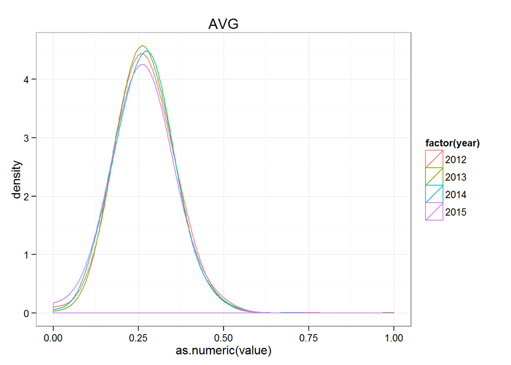

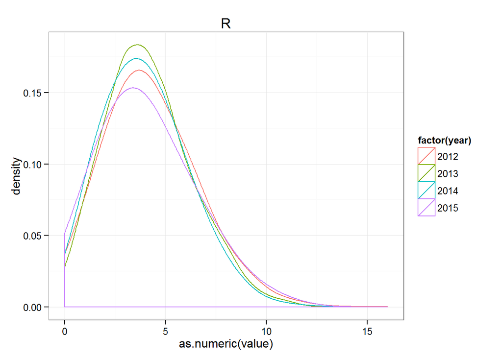

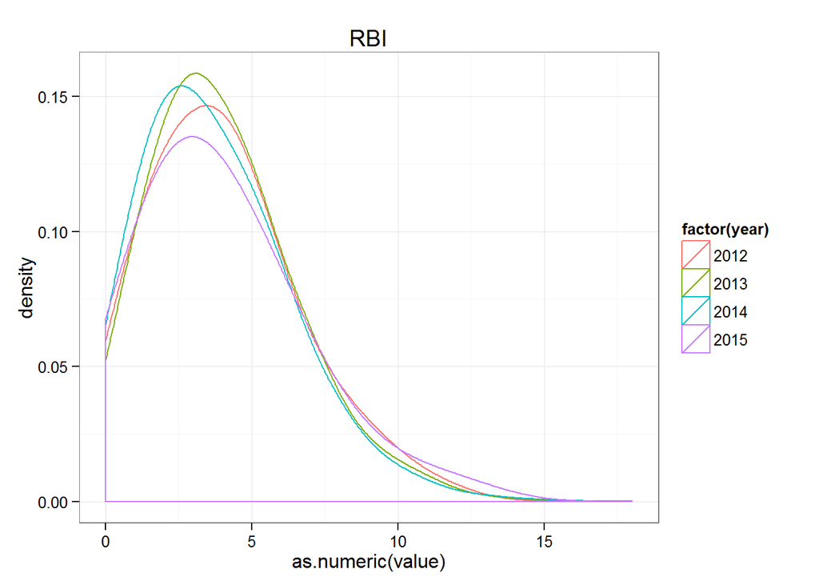

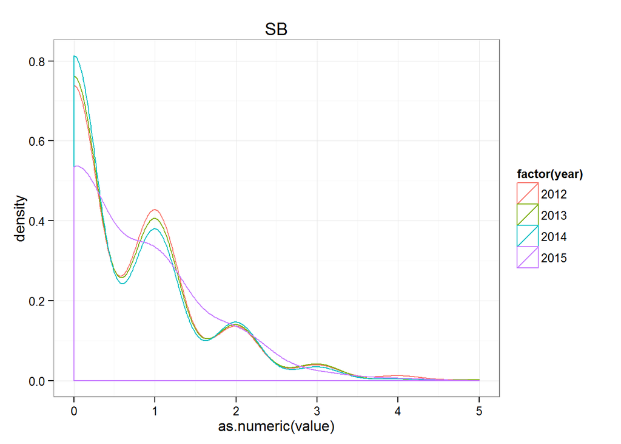

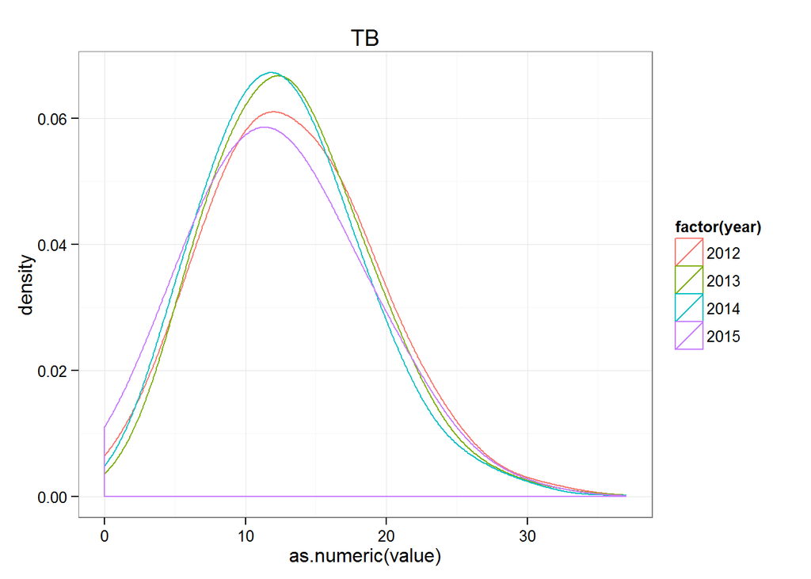

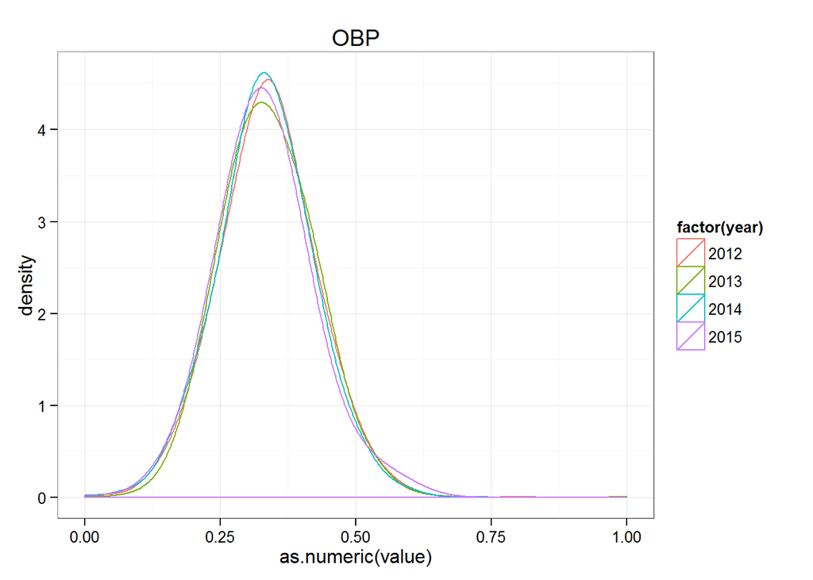

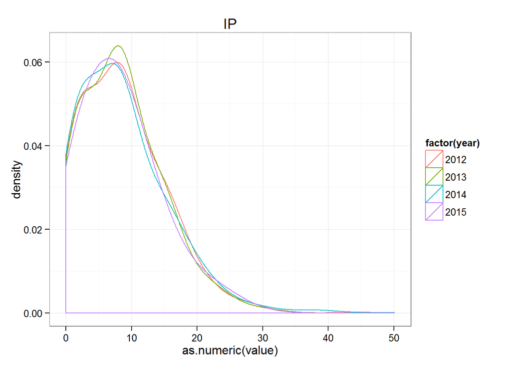

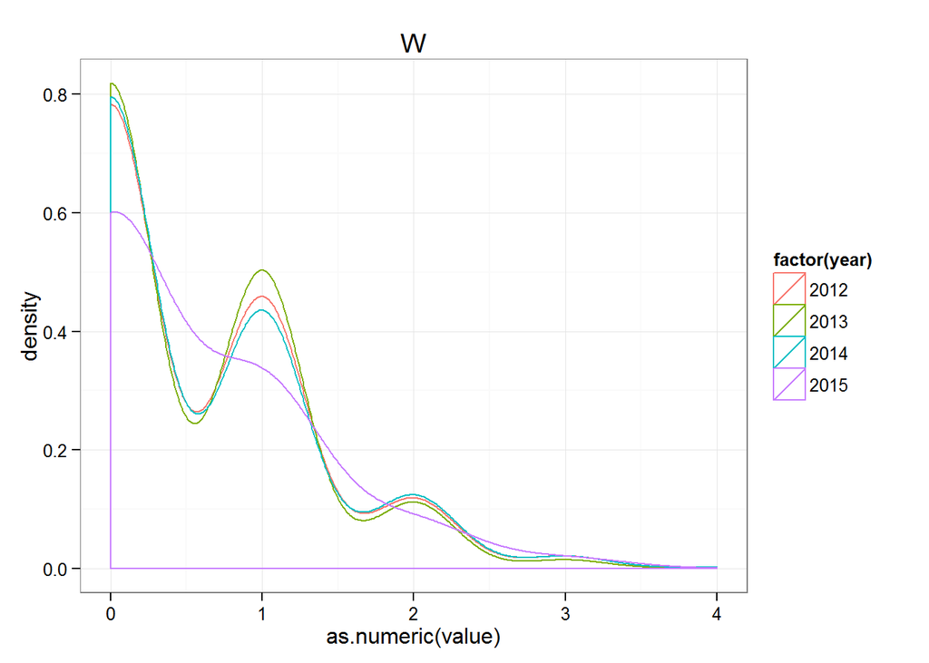

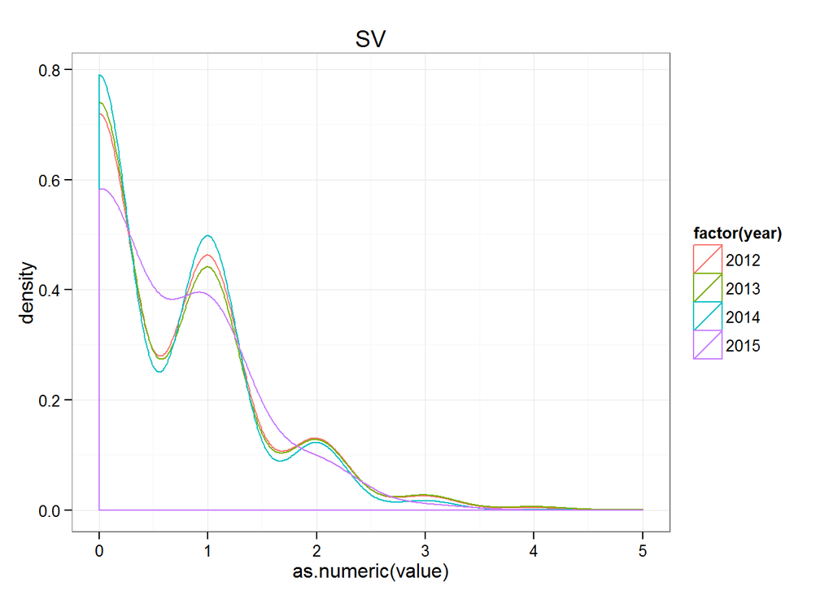

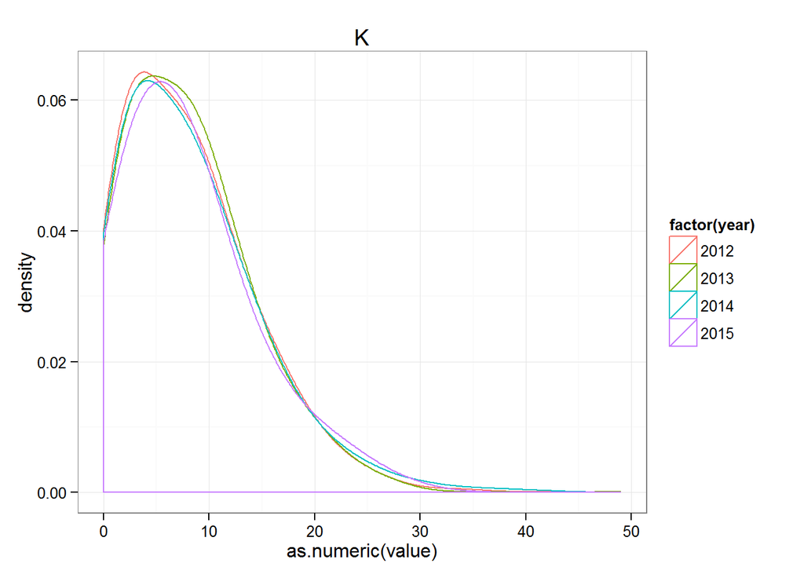

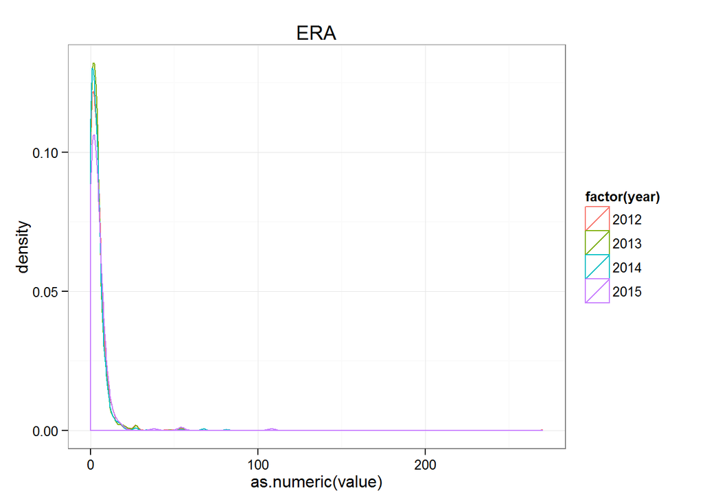

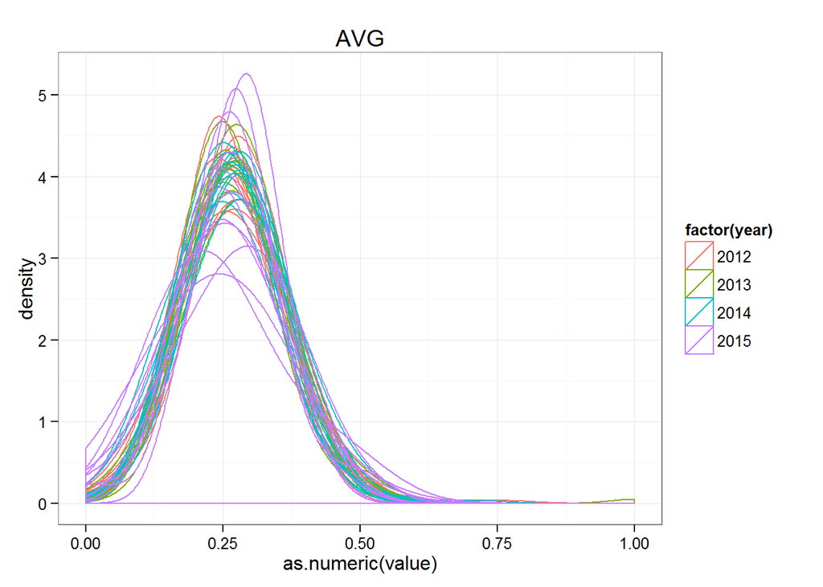

[10 more figures not shown]

# the problem

we have several thousand daily observations of team earned run average for fantasy teams. unlike real teams, innings pitched on any given day is highly variable. sometimes, a RP will only pitch a fraction of an inning. other times, multiple starting pitchers will throw 20 or more innings. here is a histogram of IP, rounded up to the nearest inning.

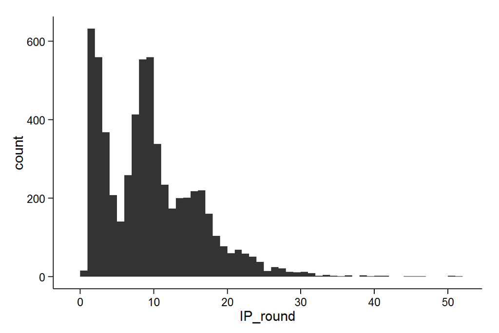

```r
ggplot(
  data = ip_df,
  aes(x = IP_round)
) +
geom_histogram(binwidth = 1) +
theme_classic()
```

you can see a spike for a handful of relievers around 1-3 innings; a spike for SP (plus a spare reliever or two) from 7-12 IP, and then things fall off after ~ 25 innings.

when we have so many small IP totals, ERA (a rate) can be really noisy. this is especially pronounced with ERA, because by convention it is reported as a rate projected out to 9 IP – for instance, if you give up 2 runs in 1 inning, that’s reported as ERA 18 - because a pitcher who gave up 2 runs every inning would give up 18 runs in a 9 inning game.

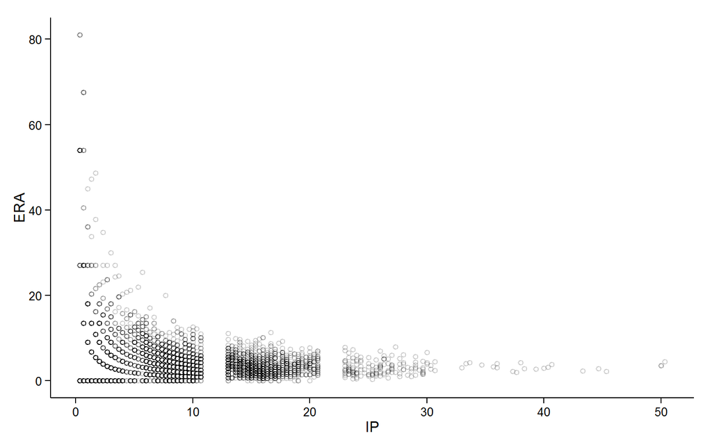

```r
ggplot(
  data = ip_df[ip_df$ERA < 100, ],
  aes(x = IP, y = ERA)
) +
geom_point(
  shape = 1,
  alpha = 0.2
) +
theme_classic()
```

what I want to do is reduce that data to one dimension, so that a given team’s ERA can be expressed as a percentile. obviously, using the raw ERA data is not the way to go - a team who pitches 10 innings at an ERA of 13 is a much worse than a team that pitches 2 innings, giving up 3 runs, for an ERA of 13.5.

In this case, we’re going to have really good priors - we’ll take them from our observed data. We need a prior for the mean and standard deviation runs allowed per out.

let’s look at that distribution

```
## stat_bin: binwidth defaulted to range/30. Use 'binwidth = x' to adjust this.
```

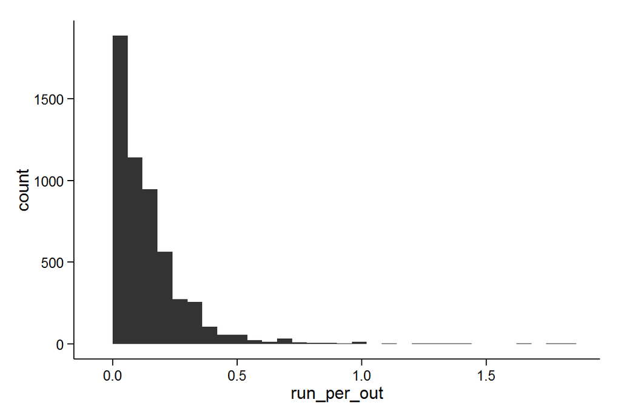

```r
ggplot(
  data = ip_df %>% dplyr::filter(IP >= 1),
  aes(x = run_per_out)
) +
geom_histogram() +
theme_classic()
```

at first glance - this is count data, so we can model runs allowed as [independent poisson variables](http://wwwf.imperial.ac.uk/~ejm/M3S4/Problems/football.pdf)!

but that’s not the right move here. recall from above that the data here mixes observations of different durations. the right way, I think, to model this is to bin by IP, and then see if the mean and sd converge as IP increases.

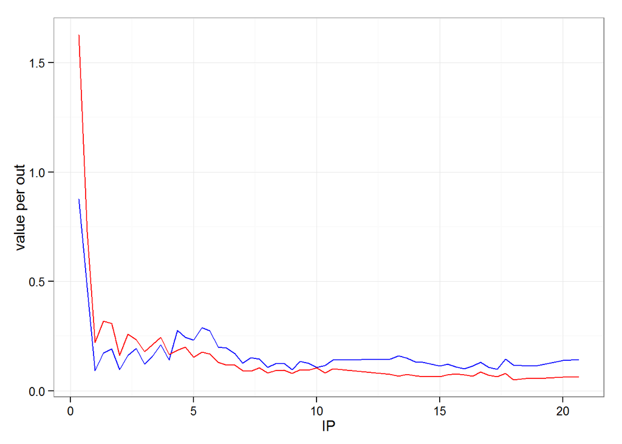

```r
ip_sum <- ip_df %>%
  dplyr::group_by(IP) %>%
  dplyr::summarize(
    n = n(),
    mean_run_per_out = mean(run_per_out, na.rm = TRUE),
    sd_run_per_out = sd(run_per_out, na.rm = TRUE)
  )

ggplot(
  data = ip_sum %>% dplyr::filter(n >= 25),
  aes(
    x = IP
  )
) +
geom_line(
  aes(y = mean_run_per_out),
  color = 'blue'
) +
geom_line(
  aes(y = sd_run_per_out),
  color = 'red'
) +
theme_bw() +
labs(y = 'value per out', x = 'IP')
```

blue is mean runs allowed, red is standard deviation. as expectd, the values definitely stabilize as IP increase. we’ll use those as priors in our model.

let’s look at the full distribution:

```r
library(moments)
```

```
## stat_bin: binwidth defaulted to range/30. Use 'binwidth = x' to adjust this.
```

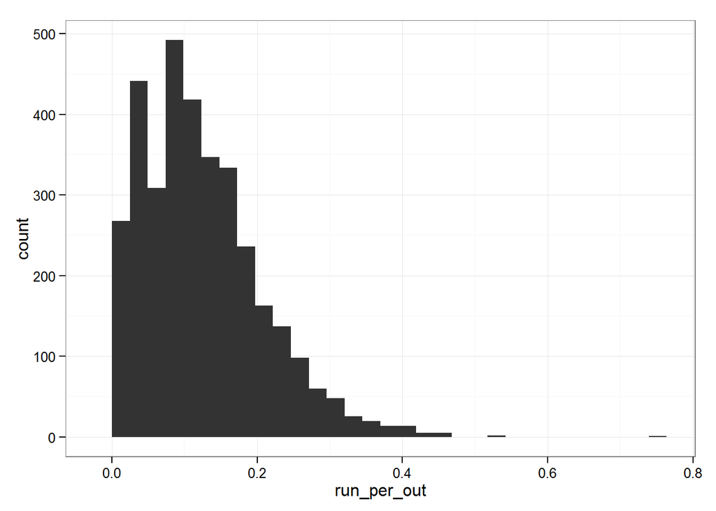

```r
prior_df <- ip_df %>%
  dplyr::filter(
    IP_round >= 8  & !is.na(run_per_out)
  ) %>% as.data.frame()

ggplot(
  data = prior_df,
  aes(
    x = run_per_out
  )
) +
geom_histogram() +
theme_bw()
```

sort of fell down the R rabbit hole of fitting distributions here. this looks like a lognormal distribution, but there are zeros?

what if we move the zeros to half of the [smallest positive observation](http://stats.stackexchange.com/a/16867/3320), and then refit?

```r
#minimum non-zero value os 0.0133
prior_df %>% dplyr::filter(
  run_per_out > 0
) %>% dplyr::summarize(
  min_run = min(run_per_out)
)
```

```
##      min_run
## 1 0.01333333
```

```r
prior_df[prior_df$run_per_out == 0, 'run_per_out'] <- 0.0133 / 2

library(fitdistrplus)
```

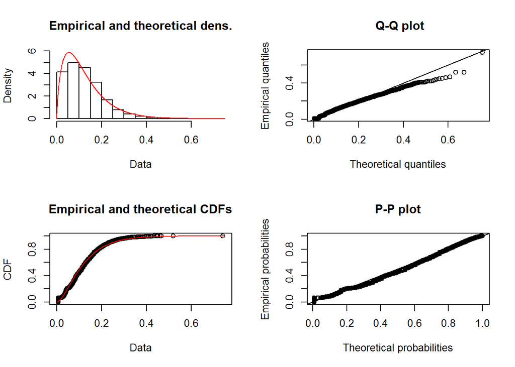

```r
fit <- fitdist(prior_df$run_per_out, "gamma")
plot(fit)
```

which makes sense - our data is, indeed, the sum of a Poisson process.

now we want to simulate draws from our data:

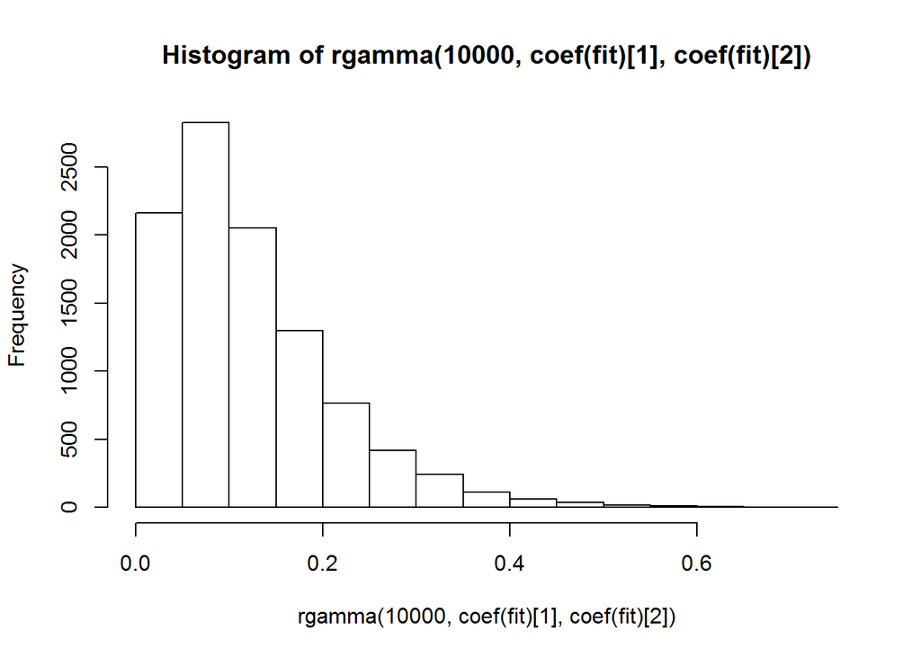

```r
hist(rgamma(10000, coef(fit)[1], coef(fit)[2]))
```

ok, so that’s our prior for true ERA. but remember the rub of our problem is that we often don’t see enough of this data to see the true ERA - lots of our samples have only one or two IP. so now we’ll build a generative model, using this data and distribution of IPs. with that generative model we can do approximate bayesian calculation to get an *estimate* of the true ERA, given our imperfect, noisy data.

rather than try to simulate the oddly shaped IP distribution (some weird mixture of gaussians?), we’ll just take random draws from the ~6700 observed values.

```r
valid_ip <- ip_df %>% dplyr::filter(IP > 0)

era_sim <- replicate(100000, {
  sim_run_per_out <- rgamma(1, coef(fit)[1], coef(fit)[2])
  sim_true_era <- sim_run_per_out * 27
  sim_outs_recorded <- round(sample_n(valid_ip, 1)$IP * 3, 0)

  sim_runs <- rpois(sim_outs_recorded, sim_run_per_out)
  reported_era <- (sum(sim_runs) / sim_outs_recorded) * 27

  c(true_era = sim_true_era, IP = sim_outs_recorded / 3, reported_era = reported_era)
})
era_sim <- t(era_sim)
head(era_sim)
```

```
##      true_era        IP reported_era
## [1,] 4.861331  2.000000    13.500000
## [2,] 4.003497 23.000000     3.130435
## [3,] 3.926976  8.000000     4.500000
## [4,] 5.525351  6.666667     4.050000
## [5,] 6.751047 17.666667     7.132075
## [6,] 1.260559  7.666667     2.347826
```

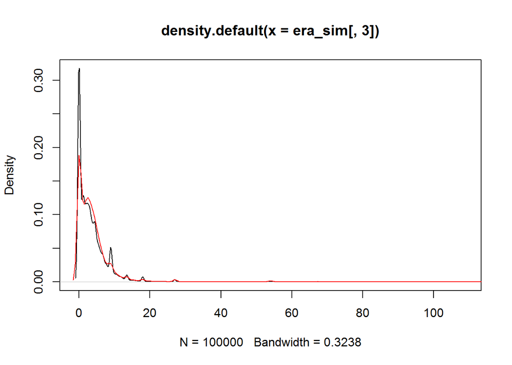

```r
p_sim <- density(era_sim[, 3])
plot(p_sim)

p_true <- density(valid_ip$ERA)
lines(p_true, col='red', new = FALSE)
```